# Task 6, Noah Christensen

I’m testing out this rmdformat, I think it looks really clean and easy to read!

## #1

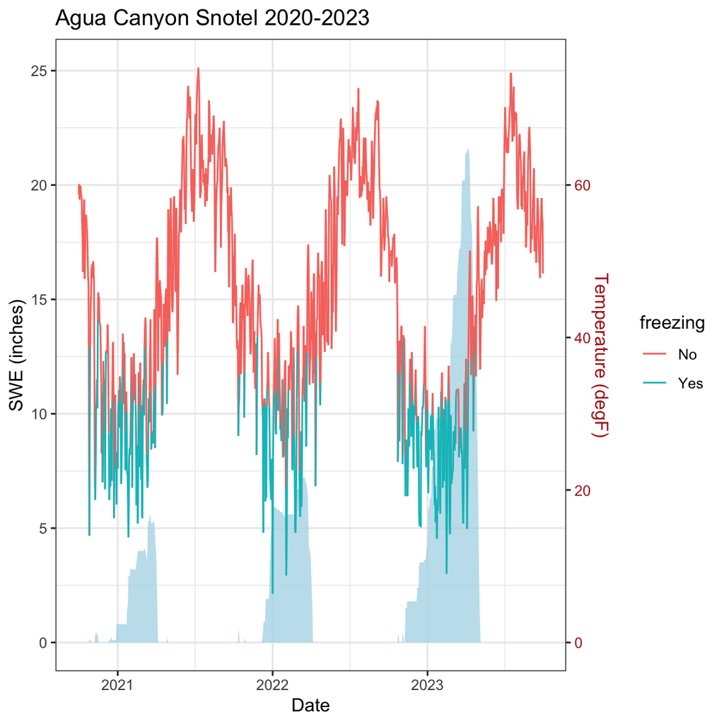

```r
library(tidyverse)

#reading in csv
df <- read.csv("../task_6/UTSNTL_ALL_2020_2022_Daily_Wide.csv")

#turning date into date format
df$Date <- as.Date(df$Date, tryFormats = "%m/%d/%y")

#creating new column to specify freezing or not
df$freezing <-ifelse(df$Agua.Canyon..907..Air.Temperature.Average..degF. < 32,"Yes","No")

#plotting
df %>%
  ggplot(aes(x = Date, y = Agua.Canyon..907..Snow.Water.Equivalent..in..Start.of.Day.Values)) +
  geom_ribbon(aes(ymin = 0, ymax = Agua.Canyon..907..Snow.Water.Equivalent..in..Start.of.Day.Values), alpha = 0.75, fill = "lightblue") +
  geom_line(aes(y = Agua.Canyon..907..Air.Temperature.Average..degF./3, color = freezing, group = 1)) +
  scale_y_continuous(name = "SWE (inches)", sec.axis = sec_axis(trans = ~.*3, name = "Temperature (degF)")) +
  theme_bw() +
  theme(axis.title.y.right = element_text(color = "firebrick"),
        axis.text.y.right = element_text(color = "firebrick")) +
  labs(title = "Agua Canyon Snotel 2020-2023")
```

(click on the plot to zoom in!)

## #2

```r
#reading in df again to remove freezing column
df <- read.csv("../task_6/UTSNTL_ALL_2020_2022_Daily_Wide.csv")

#turning date column into date format
df$Date <- as.Date(df$Date, tryFormats = "%m/%d/%y")

#pivoting longer by everything except the first two columns
df_long <- df %>% pivot_longer(2:length(df),
                    names_to = "Category",
                    values_to = "Value")


#Regular expression to extract the numbers inside of the categories
length(unique(gsub(".*\\.\\.([0-9]+)\\.\\..*", "\\1", df_long$Category)))
```

```
## [1] 137
```

```r
#There are 137 different sites with 6570 observations each
table(gsub(".*\\.\\.([0-9]+)\\.\\..*", "\\1", df_long$Category))
```

```
##
## 1013 1039 1054 1056 1065 1066 1097 1098 1099 1113 1114 1115 1116 1117 1118 1135
## 6570 6570 6570 6570 6570 6570 6570 6570 6570 6570 6570 6570 6570 6570 6570 6570
## 1145 1146 1148 1149 1151 1153 1154 1156 1162 1163 1164 1184 1192 1197 1214 1215
## 6570 6570 6570 6570 6570 6570 6570 6570 6570 6570 6570 6570 6570 6570 6570 6570
## 1216 1217 1221 1222 1223 1224 1225 1226 1227 1228 1236 1247 1248 1249 1261 1269
## 6570 6570 6570 6570 6570 6570 6570 6570 6570 6570 6570 6570 6570 6570 6570 6570
## 1278 1280 1300 1304 1308 1309  329  330  332  333  339  348  364  366  368  371
## 6570 6570 6570 6570 6570 6570 6570 6570 6570 6570 6570 6570 6570 6570 6570 6570
##  374  383  390  392  393  396  399  400  432  435  444  452  455  461  474  475
## 6570 6570 6570 6570 6570 6570 6570 6570 6570 6570 6570 6570 6570 6570 6570 6570
##  481  495  513  514  517  521  522  528  533  543  557  559  561  566  572  579
## 6570 6570 6570 6570 6570 6570 6570 6570 6570 6570 6570 6570 6570 6570 6570 6570
##  582  583  592  593  596  612  621  626  628  631  634  643  684  686  691  694
## 6570 6570 6570 6570 6570 6570 6570 6570 6570 6570 6570 6570 6570 6570 6570 6570
##  714  720  723  742  763  766  790  795  814  820  823  828  833  844  853  856
## 6570 6570 6570 6570 6570 6570 6570 6570 6570 6570 6570 6570 6570 6570 6570 6570
##  864  865  896  906  907  971  972  983  992
## 6570 6570 6570 6570 6570 6570 6570 6570 6570
```

```r
# Just checking!
900090/137
```

```
## [1] 6570
```

There are 137 different sites and each one has 6570 observations. I also divided the total number of rows (900090) by the number of sites (137) to double check that each one does actually have 6570 observations.

## #3

```r
#creating new column that specifies each year winter season
df_long$season <- cut(df_long$Date, breaks =  c(as.Date(c("2020-10-01", "2021-10-01", "2022-10-01")), Inf), labels = paste0("season_", c(1, 2, 3)))

# code that outputs 15 lines, 5 lines for each season of the locations with the most snow depth
deepest_snow <- df_long %>%
  filter(grepl("Snow.Depth", Category)) %>%
  filter(grepl("season_1", season)) %>%
  arrange(desc(Value)) %>%
  distinct(Category, .keep_all = TRUE) %>%
    mutate(Category = str_extract(Category, "^[^0-9]+") %>% str_replace_all("\\.", "")) %>% #mutating so the category column only keep everything before the numbers and deletes the dots
  slice_head(n = 5) %>%
union(
  df_long %>%
    filter(grepl("Snow.Depth", Category)) %>%
    filter(grepl("season_2", season)) %>%
    arrange(desc(Value)) %>%
    distinct(Category, .keep_all = TRUE) %>%
      mutate(Category = str_extract(Category, "^[^0-9]+") %>% str_replace_all("\\.", "")) %>%
    slice_head(n = 5)
) %>%
  union(
    df_long %>%
      filter(grepl("Snow.Depth", Category)) %>%
      filter(grepl("season_3", season)) %>%
      arrange(desc(Value)) %>%
      distinct(Category, .keep_all = TRUE) %>%
        mutate(Category = str_extract(Category, "^[^0-9]+") %>% str_replace_all("\\.", "")) %>%
      slice_head(n = 5)
  )

deepest_snow
```

```
## # A tibble: 15 × 4
##    Date       Category      Value season
##    <date>     <chr>         <dbl> <fct>
##  1 2021-02-18 Snowbird         95 season_1
##  2 2021-02-28 TonyGroveLake    90 season_1
##  3 2021-02-18 BenLomondPeak    81 season_1
##  4 2021-02-18 LookoutPeak      78 season_1
##  5 2021-02-28 Farmington       76 season_1
##  6 2022-01-07 TonyGroveLake    86 season_2
##  7 2022-03-10 Snowbird         83 season_2
##  8 2022-04-16 UsuDocDaniel     79 season_2
##  9 2022-03-10 Farmington       72 season_2
## 10 2022-01-01 BigFlat          71 season_2
## 11 2023-04-06 Atwater         229 season_3
## 12 2023-04-05 BenLomondPeak   205 season_3
## 13 2023-04-05 Farmington      201 season_3
## 14 2023-04-05 Snowbird        199 season_3
## 15 2023-04-05 ParrishCreek    165 season_3
```

Here is a look at the top 5 snotel sites with the deepest snow depth for each season! I’ve never used the distinct function but I found it online and it is very useful! I also have never used the union function but it’s super simple to combine a table together given that you want to start at the beginning of a dataframe each time.

## #4

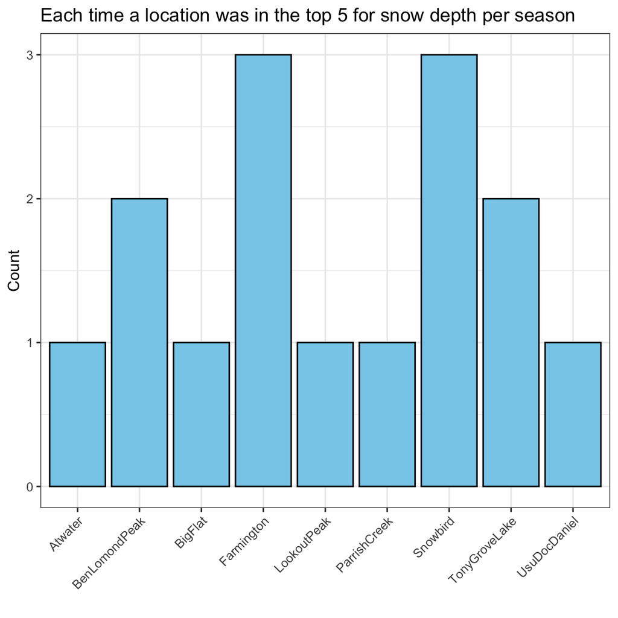

```r
deepest_snow %>%
  ggplot(aes(x = Category)) +
  geom_histogram(stat = "count", fill = "skyblue", color = "black") +
  labs(title = "Each time a location was in the top 5 for snow depth per season",
       x = "",
       y = "Count") +
  theme_bw()+
  theme(axis.text.x = element_text(angle = 45, hjust = 1))
```

Farmington and Snowbird both occurred every time as one of the top five snow depth sites for the three seasons of data.

Tony Grove Lake and Ben Lomond Peak occurred two times in the top five for the three seasons of data.

## #5

```r
#making column that specifies the type of data collection
df_long$data <- str_extract(df_long$Category, "\\d+\\.\\.(.*)")

# Remove numbers and dots
df_long$data <- str_replace_all(df_long$data, "\\d+\\.", "")

# Remove all dot at the beginning
df_long$data <- str_replace(df_long$data, "^\\.*", "")

# Remove dot at the end
df_long$data <- str_replace(df_long$data, "\\.$", "")

#turning all . into _
df_long$data <- gsub("\\.","_",df_long$data)

#keeping everything before the numbers in the category column
df_long <- df_long %>%
  mutate(location = str_extract(Category, "^[^0-9]+"))

#removing trailing dots in the Category column
df_long$location <- gsub("\\.+$", "", df_long$location)

#changing middle . to _
df_long$location <- gsub("\\.", "_", df_long$location)

#removing "category" column
df_long <- df_long %>% select(-Category)

#reading in elevation data
elev_df <- read.csv("../task_6/UTSNTL_ELEV.csv")

#turning all empty spaces to underscores
elev_df$names <- gsub(" ","_",elev_df$names)

#trying out the anti_join function
different_rows <- anti_join(df_long, elev_df, by = c("location" = "names"))
unique(different_rows$location)
```

```
##  [1] "Black_Flat_U_M__Ck"   "Chalk_Creek"          "Clear_Creek"
##  [4] "Daniels_Strawberry"   "Hole_in_Rock"         "Lakefork"
##  [7] "Lasal_Mountain_Lower" "Mammoth_Cottonwood"   "Mill_D_North"
## [10] "Mosby_Mtn"            "Payson_R_S"           "Rocky_Basin_Settleme"
## [13] "White_River"          "Widtsoe"
```

```r
#This has 14 variable and the full join has 151. This makes sense as there was only 137 different locations in the df_long

#full joining the elevation to the long dataframe
full_df <- full_join(df_long, elev_df, by = c("location" = "names"))

#showing that most of the locations now have an elevation
full_df %>%
  distinct(location, .keep_all = TRUE) %>%
  select(location,elevation_ft) %>%
  print(n=151)
```

```
## # A tibble: 151 × 2
##     location             elevation_ft
##     <chr>                       <int>
##   1 Agua_Canyon                  8900
##   2 Atwater                      8753
##   3 Bear_River_RS                8777
##   4 Beaver_Dams                  7990
##   5 Beaver_Divide                8280
##   6 Ben_Lomond_Peak              7689
##   7 Ben_Lomond_Trail             5972
##   8 Bevans_Cabin                 6520
##   9 Big_Flat                    10349
##  10 Black_Flat_U_M__Ck             NA
##  11 Blacks_Fork_Jct              8869
##  12 Bobs_Hollow                  9319
```

[output cut: 139 more lines]

You can see that not all of the locations have an elevation, this is because both of the dataframes contain some different locations.

I used the anti_join function to see which locations were not in both and there were 14 locations, this makes sense as I found 137 earlier in this document and 151 total after combining with the elevation (151-14 = 137).

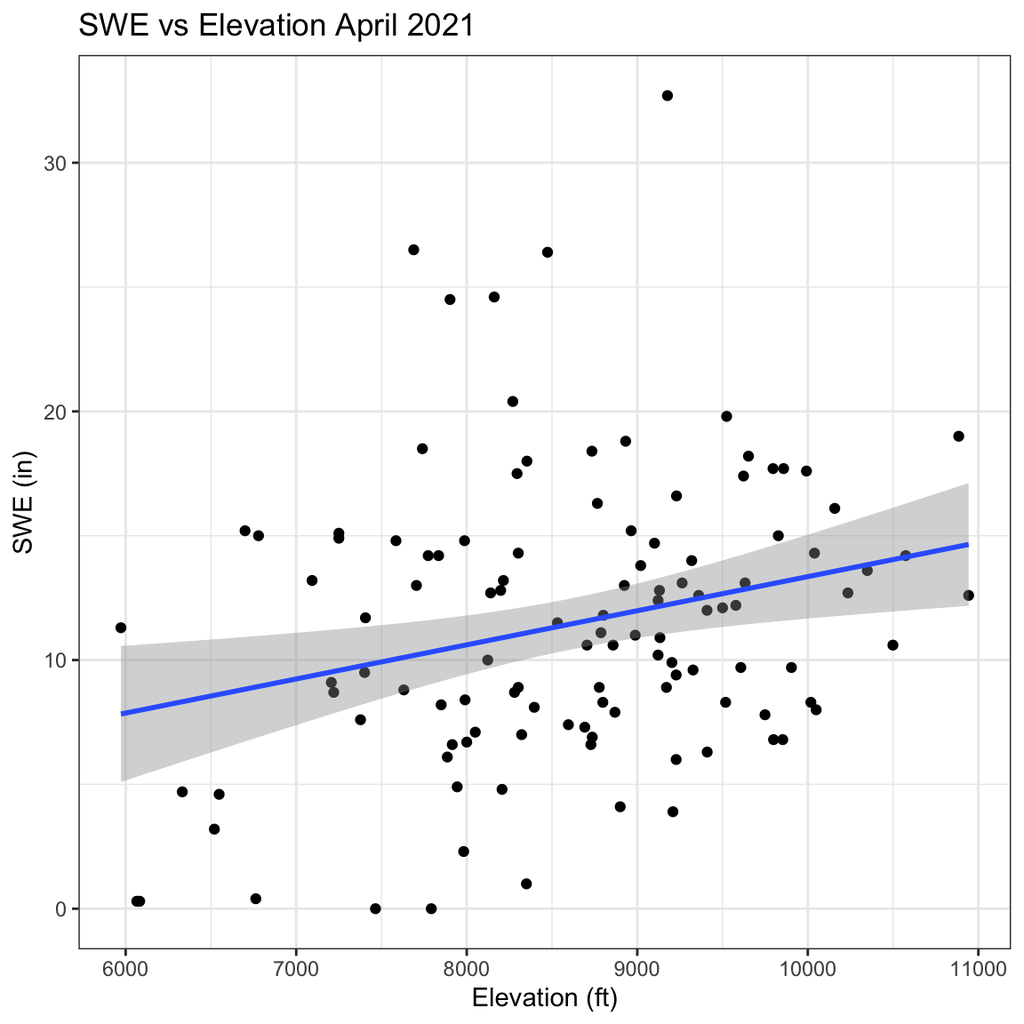

```r
#creating 2021 april snow water equivalent dataframe
swe_2021_april <- full_df %>%
  filter(Date >= "2021-04-01" & Date < "2021-05-01") %>%
  filter(str_detect(data, "Snow_Water_Equi")) %>%
  arrange(desc(Value)) %>%
  distinct(location, .keep_all = TRUE)

swe_2021_april %>%
  ggplot(aes(x=elevation_ft,y=Value)) +
  geom_point() +
  geom_smooth(method = "lm") +
  theme_bw() +
  labs(x="Elevation (ft)",
       y= "SWE (in)",
       title = "SWE vs Elevation April 2021")
```

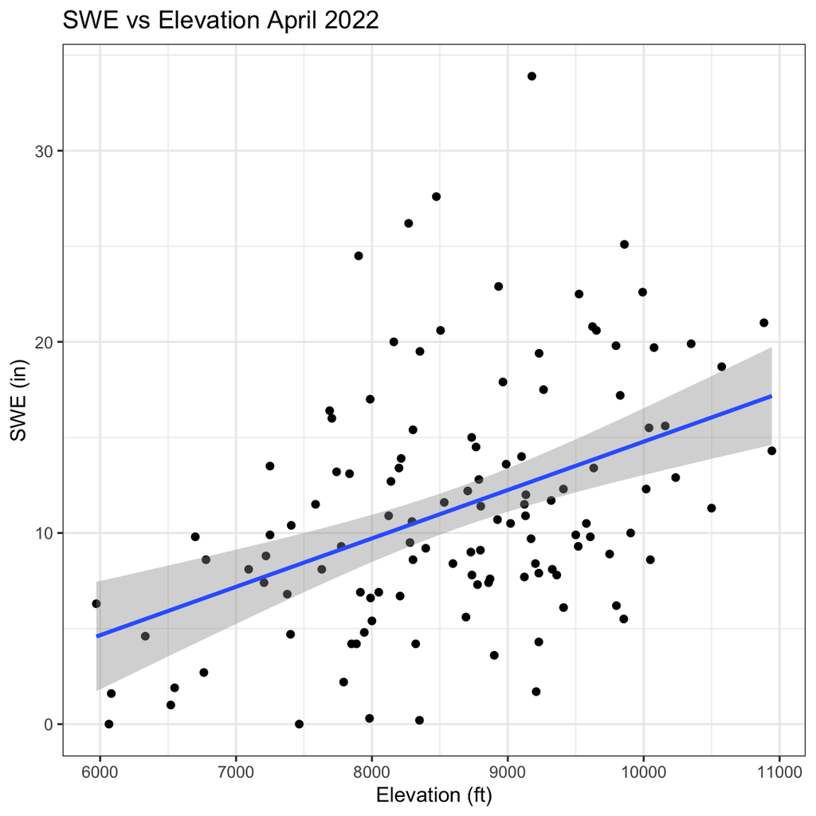

```r
#creating 2022 april snow water equivalent dataframe
swe_2022_april <- full_df %>%
  filter(Date >= "2022-04-01" & Date < "2022-05-01") %>%
  filter(str_detect(data, "Snow_Water_Equi")) %>%
  arrange(desc(Value)) %>%
  distinct(location, .keep_all = TRUE)

swe_2022_april %>%
  ggplot(aes(x=elevation_ft,y=Value)) +
  geom_point() +
  geom_smooth(method = "lm") +
  theme_bw() +
  labs(x="Elevation (ft)",
       y= "SWE (in)",
       title = "SWE vs Elevation April 2022")
```

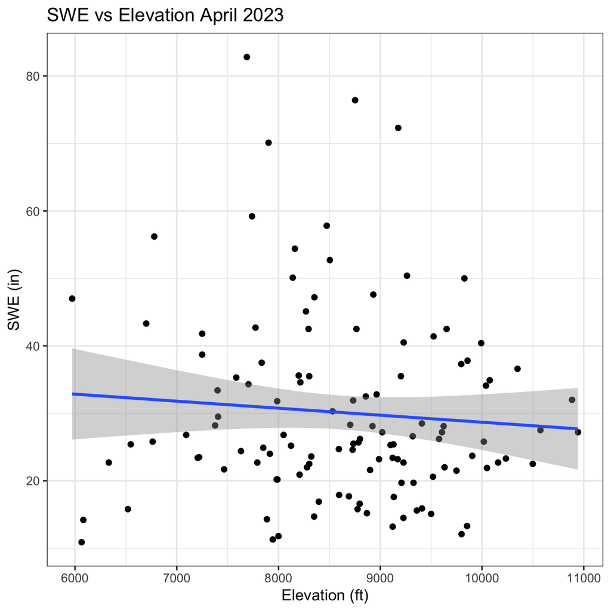

```r
#creating 2023 april snow water equivalent dataframe
swe_2023_april <- full_df %>%
  filter(Date >= "2023-04-01" & Date < "2023-05-01") %>%
  filter(str_detect(data, "Snow_Water_Equi")) %>%
  arrange(desc(Value)) %>%
  distinct(location, .keep_all = TRUE)

swe_2023_april %>%
  ggplot(aes(x=elevation_ft,y=Value)) +
  geom_point() +
  geom_smooth(method = "lm") +
  theme_bw() +
  labs(x="Elevation (ft)",
       y= "SWE (in)",
       title = "SWE vs Elevation April 2023")
```

Here are three plots for each season of the highest snow water equivalent for each site compares to their elevation.

## #6

```r
#summary of linear model for april 2021, 2022, and 2023 swe by elevation
summary(lm(Value~elevation_ft,swe_2021_april))
```

```
##
## Call:
## lm(formula = Value ~ elevation_ft, data = swe_2021_april)
##
## Residuals:
##      Min       1Q   Median       3Q      Max
## -10.3259  -3.8968  -0.5835   3.5570  20.4741
##
## Coefficients:
##                Estimate Std. Error t value Pr(>|t|)
## (Intercept)  -0.3636747  4.2091344  -0.086  0.93130
## elevation_ft  0.0013719  0.0004853   2.827  0.00555 **
## ---
## Signif. codes:  0 '***' 0.001 '**' 0.01 '*' 0.05 '.' 0.1 ' ' 1
##
## Residual standard error: 5.588 on 114 degrees of freedom
##   (18 observations deleted due to missingness)
## Multiple R-squared:  0.06551,    Adjusted R-squared:  0.05731
## F-statistic: 7.992 on 1 and 114 DF,  p-value: 0.005551
```

```r
summary(lm(Value~elevation_ft,swe_2022_april))
```

```
##
## Call:
## lm(formula = Value ~ elevation_ft, data = swe_2022_april)
##
## Residuals:
##      Min       1Q   Median       3Q      Max
## -11.0780  -4.3029  -0.9552   3.3255  21.2030
##
## Coefficients:
##                Estimate Std. Error t value Pr(>|t|)
## (Intercept)  -1.054e+01  4.393e+00  -2.399    0.018 *
## elevation_ft  2.532e-03  5.058e-04   5.006    2e-06 ***
## ---
## Signif. codes:  0 '***' 0.001 '**' 0.01 '*' 0.05 '.' 0.1 ' ' 1
##
## Residual standard error: 5.871 on 116 degrees of freedom
##   (16 observations deleted due to missingness)
## Multiple R-squared:  0.1776, Adjusted R-squared:  0.1706
## F-statistic: 25.06 on 1 and 116 DF,  p-value: 2.003e-06
```

```r
summary(lm(Value~elevation_ft,swe_2023_april))
```

```
##
## Call:
## lm(formula = Value ~ elevation_ft, data = swe_2023_april)
##
## Residuals:
##     Min      1Q  Median      3Q     Max
## -21.873  -8.325  -4.047   6.365  51.716
##
## Coefficients:
##               Estimate Std. Error t value Pr(>|t|)
## (Intercept)  39.079210  10.399088   3.758 0.000268 ***
## elevation_ft -0.001040   0.001197  -0.868 0.386923
## ---
## Signif. codes:  0 '***' 0.001 '**' 0.01 '*' 0.05 '.' 0.1 ' ' 1
##
## Residual standard error: 13.9 on 118 degrees of freedom
##   (14 observations deleted due to missingness)
## Multiple R-squared:  0.006351,   Adjusted R-squared:  -0.00207
## F-statistic: 0.7542 on 1 and 118 DF,  p-value: 0.3869
```

Looking at the summary of the linear model for each of these, the 2021 and 2022 April models do show a decent correlation with a p-value significantly less than 0.05

I’m thinking these discrepancies in the relationship between elevation and SWE are due local features such as the hillslope directions and just a year by year randomness. We are only looking at three years, I’m assuming if we looked at a few decades of data it would show a more definitive correlation between elevation and SWE.